# Furcifer pardalis Body Color Inheritance Theory

Jonathan Hill

2022-07-23

# TLDR;

1. Most individuals have multiple body and bar colors because the complete absence of any given color is extremely rare. The distribution can only be *estimated* with lineage information.
2. Offspring can have more of a given color than either of their parents (just like a human child can be taller than BOTH parents)
3. Environmental factors, like being raised in groups vs raised individually, can have a significant impact on the color of the animal, just like height, eye color and disease resistance in humans (hint: they are polygenic traits too!)
4. There are no dominant or recessive genes that control color in Furcifer pardalis (Panther Chameleons), just contributing alleles and non-contributing alleles. They have an additive result within a continuous distribution, not a discrete outcome. This means there are no alleles which skip a generation and express themselves when combined with a second recessive allele. They either contribute a color or they don’t.
5. This article purposely avoids discussing traits like red rain, color changes based on mood, and what I call a “sheen” (when one color melts into another color and appears to be a third color from a distance). Furcifer pardalis are complicated…

# Introduction

Furcifer pardalis do not exhibit simple dominant, co-dominant or recessive trait inheritance of their body color. As you can see from our [past clutches](https://ipardalis.com/categories/past-clutches/), every single individual is completely unique. They all lie on a spectrum with a huge variety of outcomes. You cannot look at their phenotype and learn anything exact about their genotype. That is because their body color is polygenic. Every phenotype is the expression of a collection of genes instead of the dominance of/interaction between one or two genes.

In humans, a good example of a polygenic trait is height. It is why a child can be taller than BOTH parents, but they’re usually around the same range. Many polygenic traits, like height, are also extremely sensitive to environmental factors. Polygenic traits force us to talk about distributions of possibilities instead of discrete outcomes. Given that I breed panther chameleons, but I work as a data scientist, I am excited to bring some of my work home with me so to speak ;).

The following theory about how body color is inherited in Furcifer pardalis (Panther Chameleons) will hopefully help explain it and dispel a few common myths about where their body color comes from. We will purposely avoid color changes which occur during excitement, relaxation, basking, mating, sleeping etc. However, it is safe to say those have a genetic component, and we could dig into it at some point.

# Why not use Mendelian Traits?

Gregor Mendel did some of the earliest genetics experiments by hybridizing pea plants in the 1800s (check out [this explanation](https://en.wikipedia.org/wiki/Mendelian_inheritance) for more detail). He discovered that there was a clear pattern to various traits such as flower color and the height of the plants. Mendel purposely created a hybrid generation of plants and then crossed those hybrids to see what traits were present in subsequent generations. Some traits seemed to dominate others with a ratio of 3:1 in the F2 generation whereas others followed a 1:2:1 pattern that he called in-complete dominance (co-dominance).

The Ambilobe locale has 4 body colors: red, orange, yellow and green. Lets say, for the sake of testing a Mendelian trait inheritance pattern, red is `RR`, orange is `OO`, yellow is `YY`, and green is `GG`. Lowercase letters represent animals without red, orange, yellow or green on their bodies and we use double letters to represent different intensity levels of a given color. A heterozygous red (`Rr`) would be less brightly colored than a homozygous red (`RR`).

Let’s say we breed a wild caught Ambilobe with bright green, some yellow and orange (`rrOoYyGG`) to a CB with pure yellow (`rrooYYgg`).

### Co-dominant trait

| Genotype | Description | Probability |
| --- | --- | --- |
| rrOoYYGg | very yellow, some orange and green | 25.00% |
| rrooYYGg | very yellow some green | 25.00% |
| rrOoYyGg | some orange, yellow and green | 25.00% |
| rrooYyGg | some yellow and green | 25.00% |

The co-dominant theory would have four possible outcomes.

### Dominant trait

| Genotype | Description | Probability |
| --- | --- | --- |
| rrOoYYGg, rrOoYyGg | very orange, yellow and green | 50.00% |
| rrooYYGg, rrooYyGg | very yellow and green | 50.00% |

The dominant/recessive theory would have just two possible outcomes: very orange, yellow and green or very yellow and green.

Both of these theories are false. Sometimes, a very orange bodied animal without any yellow or green will be produced by this pairing, but the probability of that is 0% in both charts above. Therefore, describing body color as a co-dominant/dominant/recessive trait is not accurate for Furcifer pardalis. There is a more complex genotype that produces the super green (`GG`) we see.

# Polygenic Inheritance

Polygenic inheritance offers the best explanation for why an extremely green animal **can** sire offspring with a lot of orange, but, on average, they will sire offspring with green bodies.

Polygenic traits lie on a continuous spectrum with additive and non-additive alleles. This helps explain why there is a continuous distribution of shades and intensities of a given color. It also helps explain why when a yellow body is paired with a red body you get a lot of animals with **both** red and yellow but very few with just one or the other color like you would if they were Mendelian traits.

For example, if three genes control the amount of green, we could represent it as `AABBCC` for the most intense and `aabbcc` for none. Each gene has two alleles and a capital letter represents an additive allele. If four genes impact the green color spectrum, `AABBCCDD` and `aabbccdd` would be the extremes and so on. The following tabset models out some genotypes with different gene counts.

### 2 Genes

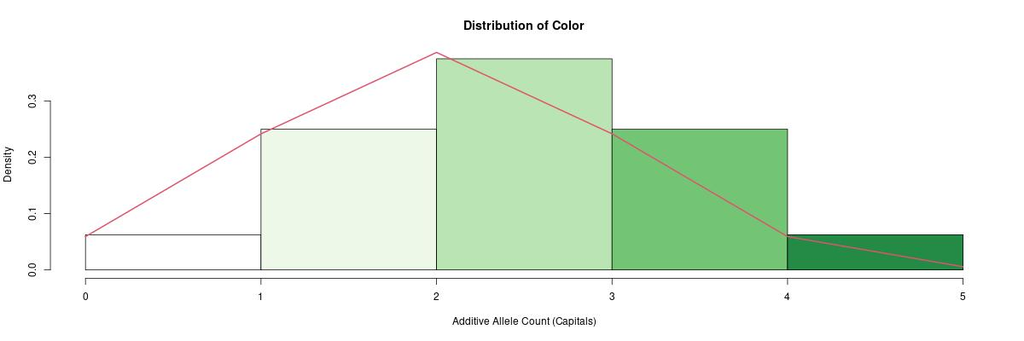

| genotype | gene1 | gene2 | capitals |
| --- | --- | --- | --- |
| aabb | aa | bb | 0 |
| aaBb | aa | Bb | 1 |
| aabB | aa | bB | 1 |
| Aabb | Aa | bb | 1 |
| aAbb | aA | bb | 1 |
| aaBB | aa | BB | 2 |
| AaBb | Aa | Bb | 2 |
| aABb | aA | Bb | 2 |
| AabB | Aa | bB | 2 |
| aAbB | aA | bB | 2 |

[output cut: 6 more lines]

### 3 Genes

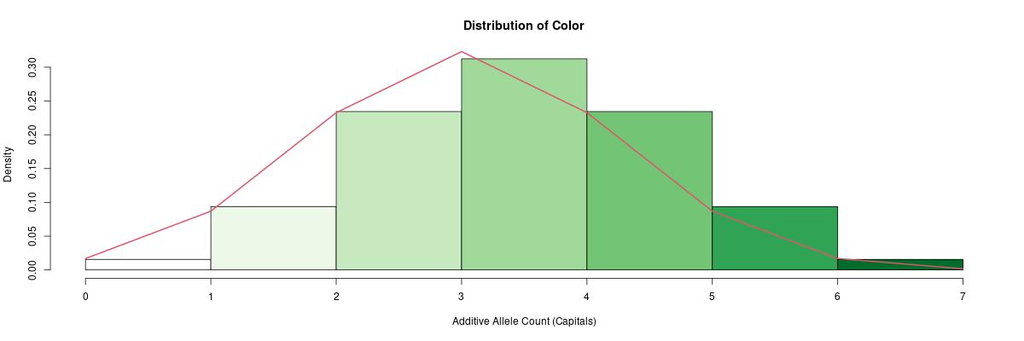

| genotype | gene1 | gene2 | gene3 | capitals |
| --- | --- | --- | --- | --- |
| aabbcc | aa | bb | cc | 0 |
| aabbCc | aa | bb | Cc | 1 |
| aabbcC | aa | bb | cC | 1 |
| aaBbcc | aa | Bb | cc | 1 |
| aabBcc | aa | bB | cc | 1 |
| Aabbcc | Aa | bb | cc | 1 |
| aAbbcc | aA | bb | cc | 1 |
| aabbCC | aa | bb | CC | 2 |
| aaBbCc | aa | Bb | Cc | 2 |
| aabBCc | aa | bB | Cc | 2 |

[output cut: 54 more lines]

### 4 Genes

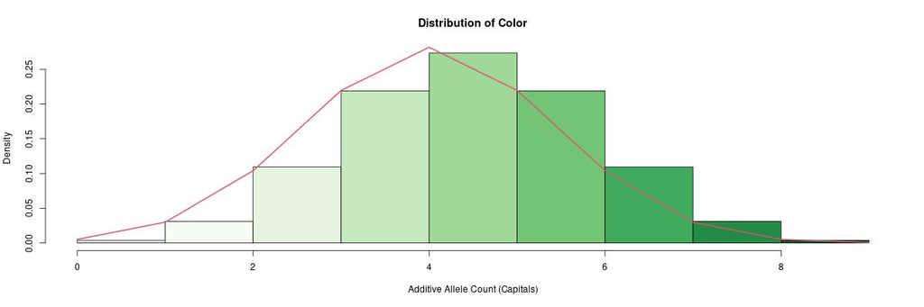

| genotype | gene1 | gene2 | gene3 | gene4 | capitals |
| --- | --- | --- | --- | --- | --- |
| aabbccdd | aa | bb | cc | dd | 0 |
| aabbccDd | aa | bb | cc | Dd | 1 |
| aabbccdD | aa | bb | cc | dD | 1 |
| aabbCcdd | aa | bb | Cc | dd | 1 |
| aabbcCdd | aa | bb | cC | dd | 1 |
| aaBbccdd | aa | Bb | cc | dd | 1 |
| aabBccdd | aa | bB | cc | dd | 1 |
| Aabbccdd | Aa | bb | cc | dd | 1 |
| aAbbccdd | aA | bb | cc | dd | 1 |
| aabbccDD | aa | bb | cc | DD | 2 |

[output cut: 246 more lines]

### 5 Genes

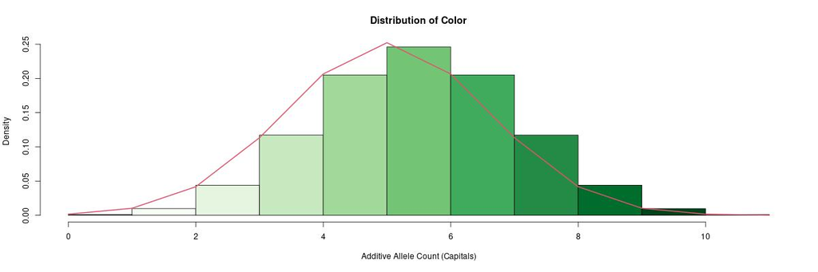

| genotype | gene1 | gene2 | gene3 | gene4 | gene5 | capitals |
| --- | --- | --- | --- | --- | --- | --- |
| aabbccddee | aa | bb | cc | dd | ee | 0 |
| aabbccddEe | aa | bb | cc | dd | Ee | 1 |
| aabbccddeE | aa | bb | cc | dd | eE | 1 |
| aabbccDdee | aa | bb | cc | Dd | ee | 1 |
| aabbccdDee | aa | bb | cc | dD | ee | 1 |
| aabbCcddee | aa | bb | Cc | dd | ee | 1 |
| aabbcCddee | aa | bb | cC | dd | ee | 1 |
| aaBbccddee | aa | Bb | cc | dd | ee | 1 |
| aabBccddee | aa | bB | cc | dd | ee | 1 |
| Aabbccddee | Aa | bb | cc | dd | ee | 1 |

[output cut: 1014 more lines]

### 6 Genes

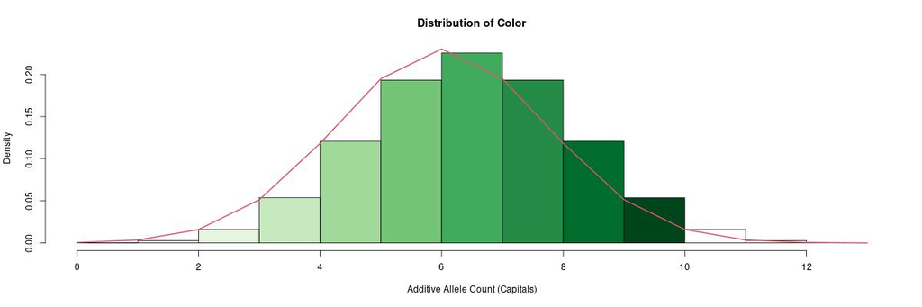

| genotype | gene1 | gene2 | gene3 | gene4 | gene5 | gene6 | capitals |
| --- | --- | --- | --- | --- | --- | --- | --- |
| aabbccddeeff | aa | bb | cc | dd | ee | ff | 0 |
| aabbccddeeFf | aa | bb | cc | dd | ee | Ff | 1 |
| aabbccddeefF | aa | bb | cc | dd | ee | fF | 1 |
| aabbccddEeff | aa | bb | cc | dd | Ee | ff | 1 |
| aabbccddeEff | aa | bb | cc | dd | eE | ff | 1 |
| aabbccDdeeff | aa | bb | cc | Dd | ee | ff | 1 |
| aabbccdDeeff | aa | bb | cc | dD | ee | ff | 1 |
| aabbCcddeeff | aa | bb | Cc | dd | ee | ff | 1 |
| aabbcCddeeff | aa | bb | cC | dd | ee | ff | 1 |
| aaBbccddeeff | aa | Bb | cc | dd | ee | ff | 1 |

[output cut: 4086 more lines]

We do not know exactly how many genes contribute to a given color spectrum, but these polygenic genotypes more accurately describe what we see. As we add more genes to a given polygenic genotype, the probability that we actually have a “pure” color at the tail of the distribution approaches zero. And it is **only** a completely pure color at the very edge of the distribution that can absolutely guarantee that color in the next gen.

Now, repeat this for every body color in the Ambilobe locale, and we have a more realistic representation of the outcomes you should expect.

# Debunked Misconceptions

Knowing that the polygenic inheritance is the best explanation for how body color is determined in Panther Chameleons helps dispel the following myths (feel free to comment in the comments section below if you can think of more).

1. Traits do not skip down the sire side of a pairing (grand sires on the sire side are irrelevant to determine body color). Once an animal is at a certain point in the distribution, that position is “sticky”. The only traits that can skip a gen are recessive traits and/or traits encoded for on a specific sex chromosome, but only express in one sex or the other. Polygenic traits do not skip generations. They are additive.
2. Males are not a pure yellow body or pure red body… every animal lies on the distribution with some small chance of producing a color you don’t see (or that you can see when you zoom in).
3. The outcome is not completely unknown, especially for animals that lie close to the tail end of a color spectrum. Those animals are very likely to pass that trait on to their offspring.
4. The female side of a pairing has two levels of uncertainty: polygenic inheritance **and** an unknown phenotype (female Furcifer pardalis do not express the male traits they carry). People often just look at a female’s sire as a proxy for her phenotype. This is a bad estimation method. You really need to see 10+ brothers as well as 3+ sires up her lineage tree to get a decent estimate for her phenotype. Because of how much variety there is in every clutch, you cannot just pick your favorite brother and use him as a proxy for her phenotype. You also need to include the ugliest of the bunch… and average the two for a decent estimate.